# Week 11

Masato Terai

作成日：2022/12/16 最終更新: 2022-12-16 19:43:27

# 課題：言語的特徴とエッセイスコアの関係を観察してみる

## 1. ICNALEで、レベルの違い（A2, B1等）により、言語的特徴が違うだろうか？

### データの下処理の関数

```r
index9DF <- function(){

  file.zenbu <- NULL
  result <- NULL
  index <- NULL

  fileV <- NULL
  typeV  <- NULL
  tokenV <- NULL
  ttrV   <- NULL
  giV    <- NULL
  awlV   <- NULL
  aslV   <- NULL
  nosV   <- NULL

  ruiseki <- NULL

  file.zenbu <- list.files()

  for (i in file.zenbu){

    yomikomi <- readLines(i, warn=F, encoding = "UTF-8")
    chunk <- unlist(strsplit(yomikomi, "[.?!] "))
    ruiseki <- c(ruiseki, chunk)

    tmp2 <- gsub("[[:punct:]]", "", ruiseki)

    tmp2 <- gsub("[[:space:]] +", " ", tmp2)          # ★重複するスペースを一つに
    tmp2 <- gsub("[[:digit:]]+", "", tmp2)
    tmp3 <- tolower(tmp2)
    tmp4 <- strsplit(tmp3, " ")
    tmp5 <- unlist(tmp4)

    token <- sort(tmp5)
    type <- unique(token)

    ttr <- length(type)/length(token)

    GI <- length(type)/sqrt(length(token))

    NS <- length(ruiseki)

    ASL <- length(token)/length(ruiseki)

    AWL <- nchar(paste(token, collapse=""))/length(token)

    # 各数値をベクトルに入れる

    fileV <- c(fileV, i)
    typeV <- c(typeV, length(type))
    tokenV <- c(tokenV, length(token))
    ttrV   <- c(ttrV, ttr)
    giV    <- c(giV, GI)
    awlV   <- c(awlV, AWL)
    aslV   <- c(aslV, ASL)
    nosV   <- c(nosV, NS)

  }
  #return(result)

  # 最後に全部をデータフレームにまとめる
  data.frame(
    fileV, typeV, tokenV, ttrV, giV, awlV, aslV, nosV)
}
```

### A2のデータを追加

```r
setwd("C:/Users/mtera/Documents/sugiura_r_2022/ICNALE_Written_Essays_2.4/Unmerged_classified/ICNALE_W_JPN_A2_0_N308")
index9.df.A2 <- index9DF()

names(index9.df.A2) <- c("ID", "Type", "Token", "TTR", "GI", "AWL", "ASL", "NoS")

index9.df.A2 <- as.tibble(index9.df.A2)
```

### データの概要

```r
summary(index9.df.A2)
```

```
##       ID                 Type          Token            TTR
##  Length:308         Min.   :  90   Min.   :  211   Min.   :0.04728
##  Class :character   1st Qu.:1454   1st Qu.:17446   1st Qu.:0.05266
##  Mode  :character   Median :1980   Median :34089   Median :0.05830
##                     Mean   :1969   Mean   :33882   Mean   :0.07612
##                     3rd Qu.:2670   3rd Qu.:50731   3rd Qu.:0.08322
##                     Max.   :3169   Max.   :67020   Max.   :0.42654
##        GI              AWL             ASL             NoS
##  Min.   : 6.196   Min.   :4.212   Min.   :11.72   Min.   :  18
##  1st Qu.:10.734   1st Qu.:4.244   1st Qu.:12.98   1st Qu.:1347
##  Median :10.977   Median :4.263   Median :13.03   Median :2599
##  Mean   :11.007   Mean   :4.281   Mean   :12.97   Mean   :2599
##  3rd Qu.:11.858   3rd Qu.:4.322   3rd Qu.:13.08   3rd Qu.:3902
##  Max.   :12.289   Max.   :4.374   Max.   :13.22   Max.   :5117
```

### B1のデータを追加

```r
setwd("C:/Users/mtera/Documents/sugiura_r_2022/ICNALE_Written_Essays_2.4/Unmerged_classified/ICNALE_W_JPN_B1_1_N358")
index9.df.B1 <- index9DF()
```

```r
names(index9.df.B1) <- c("ID", "Type", "Token", "TTR", "GI", "AWL", "ASL", "NoS")

index9.df.B1 <- as.tibble(index9.df.B1)
```

### データの概要

```r
summary(index9.df.B1)
```

```
##       ID                 Type          Token            TTR
##  Length:358         Min.   : 105   Min.   :  206   Min.   :0.04282
##  Class :character   1st Qu.:1463   1st Qu.:19811   1st Qu.:0.04712
##  Mode  :character   Median :2089   Median :39429   Median :0.05300
##                     Mean   :2067   Mean   :39158   Mean   :0.07129
##                     3rd Qu.:2754   3rd Qu.:58574   3rd Qu.:0.07389
##                     Max.   :3339   Max.   :77769   Max.   :0.50971
##        GI              AWL             ASL             NoS
##  Min.   : 7.316   Min.   :4.131   Min.   :12.32   Min.   :  16
##  1st Qu.:10.408   1st Qu.:4.268   1st Qu.:12.73   1st Qu.:1566
##  Median :10.600   Median :4.283   Median :12.82   Median :3066
##  Mean   :10.834   Mean   :4.308   Mean   :12.82   Mean   :3057
##  3rd Qu.:11.387   3rd Qu.:4.351   3rd Qu.:12.87   3rd Qu.:4598
##  Max.   :11.974   Max.   :4.408   Max.   :13.91   Max.   :6033
```

### B2のデータを追加

```r
setwd("C:/Users/mtera/Documents/sugiura_r_2022/ICNALE_Written_Essays_2.4/Unmerged_classified/ICNALE_W_JPN_B2_0_N036")
index9.df.B2 <- index9DF()
```

```r
names(index9.df.B2) <- c("ID", "Type", "Token", "TTR", "GI", "AWL", "ASL", "NoS")

index9.df.B2 <- as.tibble(index9.df.B2)
```

### データの概要

```r
summary(index9.df.B2)
```

```
##       ID                 Type            Token           TTR
##  Length:36          Min.   : 114.0   Min.   : 207   Min.   :0.1255
##  Class :character   1st Qu.: 473.2   1st Qu.:2235   1st Qu.:0.1416
##  Mode  :character   Median : 657.0   Median :4263   Median :0.1549
##                     Mean   : 650.1   Mean   :4244   Mean   :0.1925
##                     3rd Qu.: 883.5   3rd Qu.:6241   3rd Qu.:0.2120
##                     Max.   :1040.0   Max.   :8286   Max.   :0.5507
##        GI              AWL             ASL             NoS
##  Min.   : 7.924   Min.   :4.072   Min.   :12.18   Min.   : 17.0
##  1st Qu.: 9.842   1st Qu.:4.348   1st Qu.:14.43   1st Qu.:141.2
##  Median :10.113   Median :4.363   Median :14.50   Median :290.5
##  Mean   :10.242   Mean   :4.355   Mean   :14.62   Mean   :290.4
##  3rd Qu.:11.128   3rd Qu.:4.406   3rd Qu.:14.89   3rd Qu.:433.2
##  Max.   :11.425   Max.   :4.446   Max.   :15.92   Max.   :571.0
```

### A2とB1とB2を結合

```r
index9.df.merged <- rbind(index9.df.A2,index9.df.B1, index9.df.B2)
head(index9.df.merged)
```

```
## # A tibble: 6 x 8
##   ID                       Type Token   TTR    GI   AWL   ASL   NoS
##   <chr>                   <int> <int> <dbl> <dbl> <dbl> <dbl> <int>
## 1 W_JPN_PTJ0_003_A2_0.txt    90   211 0.427  6.20  4.34  11.7    18
## 2 W_JPN_PTJ0_007_A2_0.txt   142   433 0.328  6.82  4.21  12.4    35
## 3 W_JPN_PTJ0_013_A2_0.txt   189   647 0.292  7.43  4.26  12.9    50
## 4 W_JPN_PTJ0_027_A2_0.txt   239   851 0.281  8.19  4.30  12.5    68
## 5 W_JPN_PTJ0_028_A2_0.txt   266  1059 0.251  8.17  4.24  11.8    90
## 6 W_JPN_PTJ0_033_A2_0.txt   314  1287 0.244  8.75  4.23  12.7   101
```

### NAがないか調べる

- NAは含まれていない

```r
index9.df.merged %>%
  map_dbl(~ sum(is.na(.)))
```

```
##    ID  Type Token   TTR    GI   AWL   ASL   NoS
##     0     0     0     0     0     0     0     0
```

### TopicとScoreを追加

- Topicについて:

“The topics are common both for essays and spoken monologues and learner are required to show their opinions about two statements:  
(a) It is important for college students to have a part-time job.  
and (b) Smoking should be completely banned at all the restaurants in the country.”

```r
index9.df.merged <- index9.df.merged %>%
  tidyr::separate("ID" , into = c("Mode", "Language", "Topic", "ID", "CEFR", "?"), sep = "_") %>%
  dplyr::mutate(Mode = str_replace(Mode, pattern="W", replacement="Writing")) %>% #任意の値を置換
  dplyr::mutate(Topic = str_replace(Topic, pattern="PTJ0", replacement="PartTime job")) %>% #任意の値を置換
  dplyr::mutate(Topic = str_replace(Topic, pattern="SMK0", replacement="Smoking")) %>% #任意の値を置換
  dplyr::select(! "?")
```

### データの型の変換

```r
index9.df.merged %>%
  dplyr::mutate(Topic = as.factor(Topic)) %>%
  dplyr::mutate(CEFR = factor(CEFR, levels=c("A2", "B1", "B2")))
```

```
## # A tibble: 702 x 12
##    Mode    Language Topic  ID    CEFR   Type Token   TTR    GI   AWL   ASL   NoS
##    <chr>   <chr>    <fct>  <chr> <fct> <int> <int> <dbl> <dbl> <dbl> <dbl> <int>
##  1 Writing JPN      PartT~ 003   A2       90   211 0.427  6.20  4.34  11.7    18
##  2 Writing JPN      PartT~ 007   A2      142   433 0.328  6.82  4.21  12.4    35
##  3 Writing JPN      PartT~ 013   A2      189   647 0.292  7.43  4.26  12.9    50
##  4 Writing JPN      PartT~ 027   A2      239   851 0.281  8.19  4.30  12.5    68
##  5 Writing JPN      PartT~ 028   A2      266  1059 0.251  8.17  4.24  11.8    90
##  6 Writing JPN      PartT~ 033   A2      314  1287 0.244  8.75  4.23  12.7   101
##  7 Writing JPN      PartT~ 036   A2      341  1490 0.229  8.83  4.24  12.4   120
##  8 Writing JPN      PartT~ 038   A2      371  1692 0.219  9.02  4.26  12.2   139
##  9 Writing JPN      PartT~ 043   A2      384  1882 0.204  8.85  4.29  12.1   156
## 10 Writing JPN      PartT~ 052   A2      405  2084 0.194  8.87  4.30  12.4   168
## # ... with 692 more rows
```

### それぞれのファイル数の比較

- B2の数がかなり少ないことに注意

```r
table(index9.df.merged$CEFR)
```

```
##
##  A2  B1  B2
## 308 358  36
```

### スコアごとのデータを比較

#### A2 vs. B1

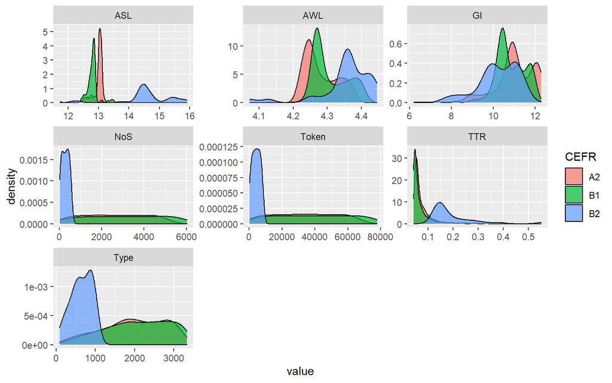

```r
index9.df.merged %>%
  pivot_longer(cols=!c(Mode, Language, Topic, ID, CEFR)) %>%
  ggplot() +
  aes(x=value, fill=CEFR) +
  geom_density(alpha=.7) +
  facet_wrap(~name, scales="free")
```

### 気付いたこと

- ICNALEは学習者のレベルのみであり、またファイル数に大きな偏りがあるため、相関分析は行わなかった。
- 熟達度が高い学習者ほど（B2）、ASL、AWL、TTRの得点が高い傾向にある。しかし、Type頻度及び、Token頻度は最も低い傾向にある。これらの傾向は、解釈に注意する必要がある。なぜならば、**B2のエッセイ数が極端に少ないことが影響していると考えられるからだ。**これらの作図ではエッセイ全体の総語数を分析しているため、エッセイ数が極端に少ないB2は相対的に語数が小さくなる。よって、Token及びType頻度も少なくなる。この影響を回避するには、分析対象の語数をある程度統一（標準化などで）する必要がある。

## 2. NICERで、トピックの違いにより、言語的特徴やスコアが違うだろうか？

```r
setwd("C:/Users/mtera/Documents/sugiura_r_2022/2020-11-24NICER1_3_2/NICER_NNS")

index9DF <- function(){

  file.zenbu <- NULL
  result <- NULL
  index <- NULL

  # ベクトルの初期化（準備）
  idV <- NULL
  topicV <- NULL                            # Topic
  scoreV <- NULL                            # Score

  typeV  <- NULL
  tokenV <- NULL
  ttrV   <- NULL
  giV    <- NULL
  awlV   <- NULL
  aslV   <- NULL
  nosV   <- NULL


  file.zenbu <- list.files()

  for (i in file.zenbu){
    yomikomi <- readLines(i, warn=F)

    topic.tmp <- grep("@Topic:", yomikomi, value=T)         # Topicの抽出
    topic <- gsub("@Topic:\t", "", topic.tmp)

    score.tmp <- grep("@Criterion:", yomikomi, value=T)     # Scoreの抽出
    score <- gsub("@Criterion:\t", "", score.tmp)

    tmp <- grep("\\*(JPN|NS)", yomikomi, value=T)
    tmp1 <- gsub("\\*(JPN|NS)...:\t", "", tmp)
    tmp2 <- gsub("[[:punct:]]", "", tmp1)
    tmp3 <- tolower(tmp2)
    tmp4 <- strsplit(tmp3, " ")
    tmp5 <- unlist(tmp4)

    token <- sort(tmp5)
    type <- unique(token)

    ttr <- length(type)/length(token)

    GI <- length(type)/sqrt(length(token))

    NS <- length(tmp)

    ASL <- length(token)/length(tmp)

    AWL <- nchar(paste(token, collapse=""))/length(token)

    # 各数値をベクトルに入れる
    idV <- c(idV, i)

    topicV <- c(topicV, topic)
    scoreV <- c(scoreV, score)

    typeV <- c(typeV, length(type))
    tokenV <- c(tokenV, length(token))
    ttrV   <- c(ttrV, ttr)
    giV    <- c(giV, GI)
    awlV   <- c(awlV, AWL)
    aslV   <- c(aslV, ASL)
    nosV   <- c(nosV, NS)

  }
  #return(result)

  # 最後に全部をデータフレームにまとめる
  data.frame(idV, topicV, scoreV, typeV, tokenV, ttrV, giV, awlV, aslV, nosV)
}
```

### 学習者のデータを追加

```r
setwd("C:/Users/mtera/Documents/sugiura_r_2022/2020-11-24NICER1_3_2/NICER_NNS")
index9.df.NICER.NNS <- index9DF()
```

```r
names(index9.df.NICER.NNS) <- c("ID", "Topic","Score","Type", "Token", "TTR", "GI", "AWL", "ASL", "NoS")
index9.df.NICER.NNS <- as.tibble(index9.df.NICER.NNS)
```

### NAがないか調べる

- NAが2つある

```r
table(index9.df.NICER.NNS$Score)
```

```
##
##   1   2   3   4   5  NA
##   2  21 169 151  36   2
```

### NAを全体の平均スコアに置き換える

#### 平均スコア

- NAを抜いたデータのスコアの平均点を四捨五入した結果、4となり、NAをScore 4で置換する

```r
index9.df.NICER.NNS %>%
  filter(Score != "NA") %>%
  mutate(Score = as.numeric(Score)) %>%
  summarise(m = round(mean(Score)))
```

```
## # A tibble: 1 x 1
##       m
##   <dbl>
## 1     4
```

```r
index9.df.NICER.NNS <- index9.df.NICER.NNS %>%
  mutate(Score = na_if(Score, "NA")) %>%
  replace_na(list(Score = 4))
```

### 言語タグを付与

```r
index9.df.NICER.NNS <- index9.df.NICER.NNS %>%
  mutate(Language = "Jap")
```

### 母語話者のデータを追加

```r
setwd("C:/Users/mtera/Documents/sugiura_r_2022/2020-11-24NICER1_3_2/NICER_NS")
index9.df.NICER.NS <- index9DF()
```

```r
names(index9.df.NICER.NS) <- c("ID", "Topic","Score","Type", "Token", "TTR", "GI", "AWL", "ASL", "NoS")
index9.df.NICER.NS <- as.tibble(index9.df.NICER.NS)
```

### NAがないか調べる

- NAが31つある

```r
table(index9.df.NICER.NS$Score)
```

```
##
##  4  5  6 NA
##  1 13 26 31
```

### NAを全体の平均スコアに置き換える

#### 平均スコア

- NAを抜いたデータのスコアの平均点を四捨五入した結果、6となり、NAをScore 6で置換する

```r
index9.df.NICER.NS %>%
  filter(Score != "NA") %>%
  mutate(Score = as.numeric(Score)) %>%
  summarise(m = round(mean(Score)))
```

```
## # A tibble: 1 x 1
##       m
##   <dbl>
## 1     6
```

```r
index9.df.NICER.NS <- index9.df.NICER.NS %>%
  mutate(Score = na_if(Score, "NA")) %>%
  replace_na(list(Score = 6))
```

### 言語タグを付与

```r
index9.df.NICER.NS <- index9.df.NICER.NS %>%
  mutate(Language = "Eng")
```

### 母語話者と学習者のデータを結合

```r
NICER.df <- rbind(index9.df.NICER.NS,index9.df.NICER.NNS)
```

### データの型の変換

- 6件法のデータを連続値とみなすか、離散値とみなすかはここでは問題にせず。のちの処理のため連続値として扱う。

```r
NICER.df <- NICER.df %>%
  dplyr::mutate(Topic = as.factor(Topic)) %>%
  dplyr::mutate(Score = as.integer(Score))
```

### データの概要

```r
summary(NICER.df)
```

```
##       ID                  Topic         Score            Type
##  Length:452         education:192   Min.   :1.000   Min.   : 49.0
##  Class :character   money    : 88   1st Qu.:3.000   1st Qu.:105.0
##  Mode  :character   sports   :172   Median :4.000   Median :130.0
##                                     Mean   :3.881   Mean   :166.7
##                                     3rd Qu.:4.000   3rd Qu.:166.2
##                                     Max.   :6.000   Max.   :764.0
##      Token             TTR               GI              AWL
##  Min.   :  85.0   Min.   :0.2531   Min.   : 4.566   Min.   :3.507
##  1st Qu.: 219.0   1st Qu.:0.4133   1st Qu.: 7.037   1st Qu.:4.207
##  Median : 277.0   Median :0.4604   Median : 7.758   Median :4.470
##  Mean   : 386.0   Mean   :0.4600   Mean   : 8.345   Mean   :4.474
##  3rd Qu.: 386.2   3rd Qu.:0.5052   3rd Qu.: 8.837   3rd Qu.:4.737
##  Max.   :2334.0   Max.   :0.6581   Max.   :15.814   Max.   :5.627
##       ASL             NoS           Language
##  Min.   : 6.96   Min.   :  7.00   Length:452
##  1st Qu.:11.10   1st Qu.: 18.00   Class :character
##  Median :13.02   Median : 22.00   Mode  :character
##  Mean   :14.24   Mean   : 25.78
##  3rd Qu.:16.05   3rd Qu.: 29.00
##  Max.   :38.00   Max.   :155.00
```

### 得点の分布

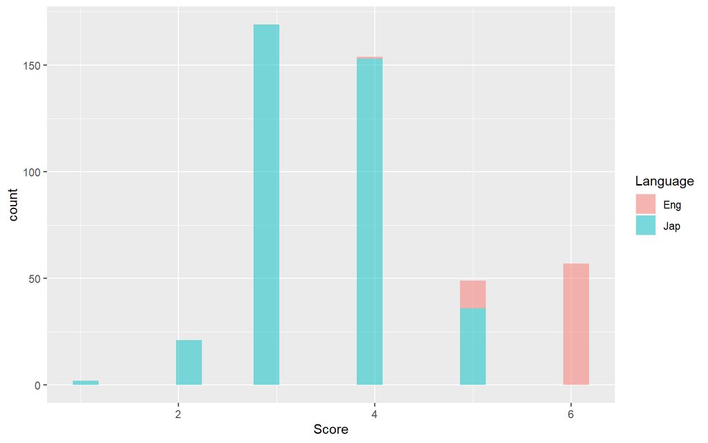

```r
NICER.df %>%
  ggplot(mapping = aes(x = Score,
                       fill = Language)) +
    geom_histogram(alpha = 0.5, bins = 20)
```

### 相関検定（母語話者）

```r
NICER.NS <- NICER.df %>%
  filter(Language == "Eng")

results <- list()
  results[[1]] <-cor.test(NICER.NS$Type, NICER.NS$Score)
  results[[2]] <-cor.test(NICER.NS$Token, NICER.NS$Score)
  results[[3]] <-cor.test(NICER.NS$TTR, NICER.NS$Score)
  results[[4]] <-cor.test(NICER.NS$GI, NICER.NS$Score)
  results[[5]] <-cor.test(NICER.NS$AWL, NICER.NS$Score)
  results[[6]] <-cor.test(NICER.NS$ASL, NICER.NS$Score)
  results[[7]] <-cor.test(NICER.NS$NoS, NICER.NS$Score)
```

```r
dat <- NULL
name <- NULL
cis.l <- NULL
cis.u <- NULL
p <- NULL

for (r in 1:length(results)) {
  cors <- results[[r]]
  nameV <- cors$data.name
  corsV <- cors$estimate
  cis.lowV <- cors$conf.int[1]
  cis.uppV <- cors$conf.int[2]
  pV <- cors$p.value

  name <- c(name, nameV)
  dat <- c(dat, corsV)
  cis.l <- c(cis.l,cis.lowV)
  cis.u <- c(cis.u, cis.uppV)
  p <- c(p, pV)

}

cortests <- data.frame(name = name,
                       estimate = dat,
                       conf.lower = cis.l,
                       conf.upper =cis.u,
                       p.value = p)
```

### 相関検定の結果

- Typeとの相関が最も大きかった
- TTRのみ負の相関がみられた

```r
cortests %>%
  arrange(desc(estimate)) %>%
   kableExtra::kbl(digits = 2)
```

| name | estimate | conf.lower | conf.upper | p.value |
| --- | --- | --- | --- | --- |
| NICER.NS$Type and NICER.NS$Score | 0.59 | 0.41 | 0.72 | 0.00 |
| NICER.NS$Token and NICER.NS$Score | 0.53 | 0.34 | 0.68 | 0.00 |
| NICER.NS$GI and NICER.NS$Score | 0.49 | 0.29 | 0.65 | 0.00 |
| NICER.NS$ASL and NICER.NS$Score | 0.33 | 0.10 | 0.52 | 0.01 |
| NICER.NS$NoS and NICER.NS$Score | 0.29 | 0.06 | 0.49 | 0.01 |
| NICER.NS$AWL and NICER.NS$Score | 0.06 | -0.18 | 0.29 | 0.63 |
| NICER.NS$TTR and NICER.NS$Score | -0.35 | -0.54 | -0.13 | 0.00 |

### 相関検定（学習者）

```r
NICER.NNS <- NICER.df %>%
  filter(Language == "Jap")

results <- list()
  results[[1]] <-cor.test(NICER.NNS$Type, NICER.NNS$Score)
  results[[2]] <-cor.test(NICER.NNS$Token, NICER.NNS$Score)
  results[[3]] <-cor.test(NICER.NNS$TTR, NICER.NNS$Score)
  results[[4]] <-cor.test(NICER.NNS$GI, NICER.NNS$Score)
  results[[5]] <-cor.test(NICER.NNS$AWL, NICER.NNS$Score)
  results[[6]] <-cor.test(NICER.NNS$ASL, NICER.NNS$Score)
  results[[7]] <-cor.test(NICER.NNS$NoS, NICER.NNS$Score)
```

```r
dat <- NULL
name <- NULL
cis.l <- NULL
cis.u <- NULL
p <- NULL

for (r in 1:length(results)) {
  cors <- results[[r]]
  nameV <- cors$data.name
  corsV <- cors$estimate
  cis.lowV <- cors$conf.int[1]
  cis.uppV <- cors$conf.int[2]
  pV <- cors$p.value

  name <- c(name, nameV)
  dat <- c(dat, corsV)
  cis.l <- c(cis.l,cis.lowV)
  cis.u <- c(cis.u, cis.uppV)
  p <- c(p, pV)

}

cortests <- data.frame(name = name,
                       estimate = dat,
                       conf.lower = cis.l,
                       conf.upper =cis.u,
                       p.value = p)
```

### 相関検定の結果

- TokenおよびTypeの順に相関係数が大きかった
- 全体的に、英語母語話者よりも相関係数の値が大きい
- TTRのみ負の相関がみられた

```r
cortests %>%
  arrange(desc(estimate)) %>%
   kableExtra::kbl(digits = 2)
```

| name | estimate | conf.lower | conf.upper | p.value |
| --- | --- | --- | --- | --- |
| NICER.NNS$Token and NICER.NNS$Score | 0.82 | 0.78 | 0.85 | 0 |
| NICER.NNS$Type and NICER.NNS$Score | 0.79 | 0.75 | 0.83 | 0 |
| NICER.NNS$NoS and NICER.NNS$Score | 0.59 | 0.52 | 0.65 | 0 |
| NICER.NNS$GI and NICER.NNS$Score | 0.53 | 0.45 | 0.60 | 0 |
| NICER.NNS$ASL and NICER.NNS$Score | 0.41 | 0.32 | 0.49 | 0 |
| NICER.NNS$AWL and NICER.NNS$Score | 0.16 | 0.06 | 0.26 | 0 |
| NICER.NNS$TTR and NICER.NNS$Score | -0.46 | -0.54 | -0.38 | 0 |

# 引用パッケージ

```r
packages <- scan_packages(path = "C:/Users/mtera/Documents/sugiura_r_2022/sugiura_friday2_2022_12_16.Rmd")
packages$pkg %>%
  map(citation) %>%
  print(style = "text")
```

```
## [[1]]
## R Core Team (2021). _R: A Language and Environment for Statistical
## Computing_. R Foundation for Statistical Computing, Vienna, Austria.
## <URL: https://www.R-project.org/>.
##
## [[2]]
## Rodriguez-Sanchez F, Jackson CP, Hutchins SD (2022). _grateful:
## Facilitate citation of R packages_. R package version 0.1.5, <URL:
## https://github.com/Pakillo/grateful>.
##
## [[3]]
## Zhu H (2021). _kableExtra: Construct Complex Table with 'kable' and
## Pipe Syntax_. R package version 1.3.4, <URL:
## https://CRAN.R-project.org/package=kableExtra>.
##
## [[4]]
## Xie Y (2022). _knitr: A General-Purpose Package for Dynamic Report
## Generation in R_. R package version 1.40, <URL:
## https://yihui.org/knitr/>.
##
## Xie Y (2015). _Dynamic Documents with R and knitr_, 2nd edition.
## Chapman and Hall/CRC, Boca Raton, Florida. ISBN 978-1498716963, <URL:
## https://yihui.org/knitr/>.
##
## Xie Y (2014). "knitr: A Comprehensive Tool for Reproducible Research in
## R." In Stodden V, Leisch F, Peng RD (eds.), _Implementing Reproducible
## Computational Research_. Chapman and Hall/CRC. ISBN 978-1466561595,
## <URL: http://www.crcpress.com/product/isbn/9781466561595>.
##
## [[5]]
## Allaire J, Xie Y, McPherson J, Luraschi J, Ushey K, Atkins A, Wickham
## H, Cheng J, Chang W, Iannone R (2022). _rmarkdown: Dynamic Documents
## for R_. R package version 2.17, <URL:
## https://github.com/rstudio/rmarkdown>.
##
## Xie Y, Allaire J, Grolemund G (2018). _R Markdown: The Definitive
## Guide_. Chapman and Hall/CRC, Boca Raton, Florida. ISBN 9781138359338,
## <URL: https://bookdown.org/yihui/rmarkdown>.
##
## Xie Y, Dervieux C, Riederer E (2020). _R Markdown Cookbook_. Chapman
## and Hall/CRC, Boca Raton, Florida. ISBN 9780367563837, <URL:
## https://bookdown.org/yihui/rmarkdown-cookbook>.
##
## [[6]]
## Barnier J (2022). _rmdformats: HTML Output Formats and Templates for
## 'rmarkdown' Documents_. R package version 1.0.4, <URL:
## https://CRAN.R-project.org/package=rmdformats>.
##
## [[7]]
## Wickham H, Averick M, Bryan J, Chang W, McGowan LD, Francois R,
## Grolemund G, Hayes A, Henry L, Hester J, Kuhn M, Pedersen TL, Miller E,
## Bache SM, Muller K, Ooms J, Robinson D, Seidel DP, Spinu V, Takahashi
## K, Vaughan D, Wilke C, Woo K, Yutani H (2019). "Welcome to the
## tidyverse." _Journal of Open Source Software_, *4*(43), 1686. doi:
## 10.21105/joss.01686 (URL: https://doi.org/10.21105/joss.01686).
```